# Woolfe Lab: Transdifferentiation of neuron

Meeta Mistry

Array analysis for Brian Wainger (brian.wainger@childrens.harvard.edu) at Woolfe Lab. Contact Meeta Mistry (mmistry@hsph.harvard.edu) for additional details. Request from client was:

> Basically we are comparing expression profiles of three populations of cells and there is a good amount of variability between replicate samples for one of the populations because it is a fibroblast-derived neuronal cell line. We would like to go a little further with the data than we have so far

## Bioconductor and R libraries used

```r
loadlibs <- function(){
library(arrayQualityMetrics)
library(RColorBrewer)
library(mogene10sttranscriptcluster.db)
library(oligo)
library(limma)
library(plyr)
library(ggplot2)
library(grid)
library(gridExtra)
library(xtable)
library(sva)
library(png)
library(gProfileR)
library(GOstats)
library(AnnotationDbi)
library(CHBUtils)
}
suppressPackageStartupMessages(loadlibs())
```

## Get variables

- get base directory for analyses
- specify data and results directories
- specify column headers used in metadata file

```r
# Setup directory variables
baseDir <- '.'
dataDir <- file.path(baseDir, "data")
metaDir <- file.path(dataDir, "meta")
resultsDir <- file.path(baseDir, "results")
```

## Load the data and metadata

```r
prevWorkDir = getwd()

setwd("data/")
pd <- read.AnnotatedDataFrame('covars.desc')
data <- read.celfiles(rownames(pData(pd)))
```

```
## Platform design info loaded.
```

```
## Reading in : DRG 1__28MoGene-1_0-st-v1_29.CEL
## Reading in : DRG 2 _28MoGene-1_0-st-v1_29.CEL
## Reading in : DRG 3 _28MoGene-1_0-st-v1_29.CEL
## Reading in : MEF 1 _28MoGene-1_0-st-v1_29.CEL
## Reading in : MEF 2 _28MoGene-1_0-st-v1_29.CEL
## Reading in : MEF 3 _28MoGene-1_0-st-v1_29.CEL
## Reading in : Mouse iNoc 2_2B _28MoGene-1_0-st-v1_29.CEL
## Reading in : Mouse iNoc 3_2B _28MoGene-1_0-st-v1_29.CEL
## Reading in : Mouse iNoc 4_2B _28MoGene-1_0-st-v1_29.CEL
## Reading in : Mouse iNoc 1_2B_batch2 _8MoGene-1_0-st-v1_29.CEL
## Reading in : Mouse iNoc 2_2B_batch2 _28MoGene-1_0-st-v1_29.CEL
## Reading in : Mouse iNoc 3_2B_batch2 _28MoGene-1_0-st-v1_29.CEL
```

```r
phenoData(data) <- pd

# Convert to factors
pData(data)$celltype <- factor(pData(data)$celltype)
pData(data)$Batch <- factor(pData(data)$Batch)

# restore previous working directory
setwd(prevWorkDir)
```

## Quality control

ArrayQualityMetrics QC report for the raw data can be found here

### Normalization

The data was pre-processed and normalized using RMA() (Robust Multiarray Analysis) algorithm. RMA is the standard method for performing background subtraction, normalization and averaging. With the processed data we find that signal intensity is more similarly distributed across the arrays. Although, based on the QC report Array #8 appears to be an outlier and will be removed for downstream analysis. Density estimates show no indication of major outliers as the smoothed histograms for each array have similar shapes and ranges. ArrayQualityMetrics QC report for the normalized data can be found here

```r
# apply rma
data.rma <- rma(data)
```

```
## Background correcting
## Normalizing
## Calculating Expression
```

```r
# Remove outliers
preparedData=prepdata(expressionset=data.rma, intgroup=c('celltype', 'Batch'),
                      do.logtransform=F)
# Boxplots
bo<- aqm.boxplot(preparedData, subsample=10000, outlierMethod= "KS")
bo.out<-bo@outliers@which
```

### PCA

Plot all pairwise combinations of the first 5 principal components for the samples. The more similar the samples are, the closer they will cluster in these plots. In the figure below cell type is coded using red=DRG; blue=iNoc; green=MEF. A second run of induced nociceptor samples were run in the second batch. Here, we see that while the data clusters well into three cell populations in the first and second principal components - but the batches are evident in PC3.

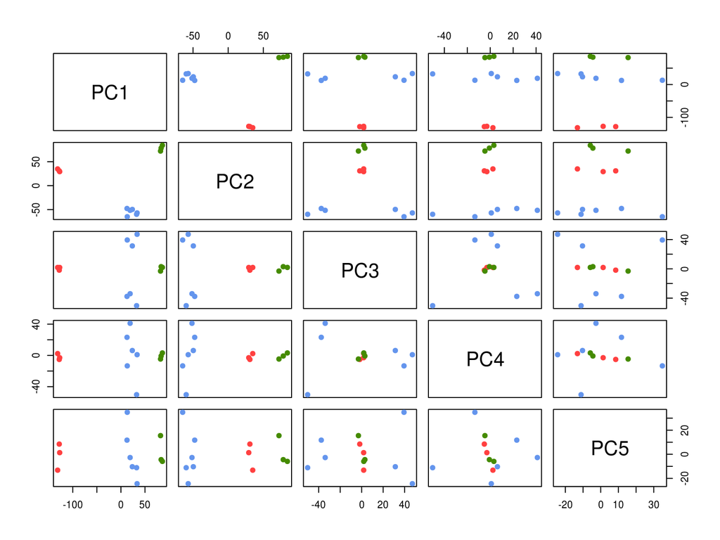

## Removing batch effects

To remove the effects we will use [ComBat](http://www.bu.edu/jlab/wp-assets/ComBat/Abstract.html) an empirical Bayes framework for adjusting the data for batch effects. EB is borrowing information across all other genes and samples in hopes that this borrowed information will lead to better estimates/stable inferences.

```
## Found 2 batches
## Found 2  categorical covariate(s)
## Standardizing Data across genes
## Fitting L/S model and finding priors
```

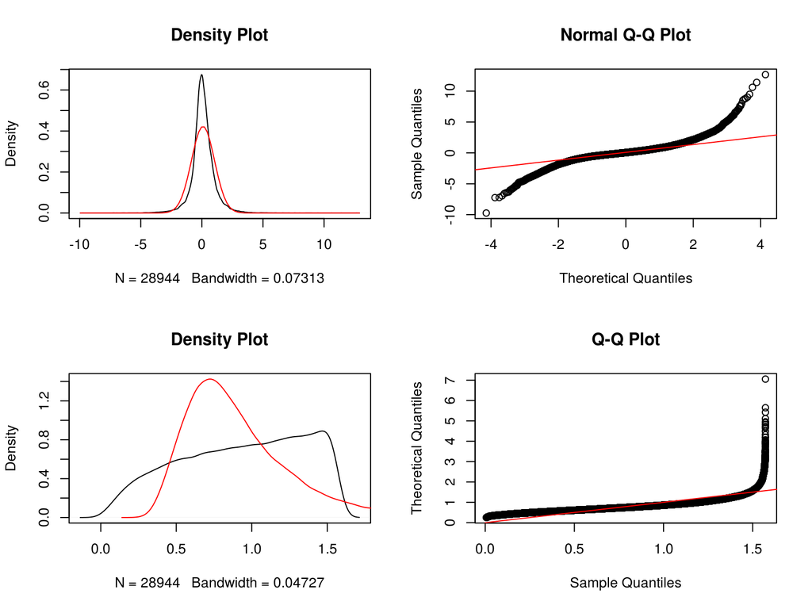

```
## Finding parametric adjustments
## Adjusting the Data
```

```r
# Load the control annotations
data(mogene10stCONTROL, package="ArrayTools")

# Remove control probes from data
gene <- data.rma[!(row.names(exprs(data.rma)) %in% mogene10stCONTROL[,1]),]

# Remove outlier sample
gene <- gene[,which(colnames(gene) %in% names(bo.out) == F)]

# Model matrix
pd <-pData(gene)
pd$FileName <- NULL
mod<-model.matrix(~celltype, data=pd)

# Batch correction
data.combat <- ComBat(exprs(gene), pd$Batch, mod, numCovs=NULL, par.prior=TRUE,prior.plots=TRUE)
```

### PCA

From the PCA plots we can see that the clustering of iNoc samples by batch has been removed by ComBat. We can proceed using this batch adjusted expression data for differential expression analysis.

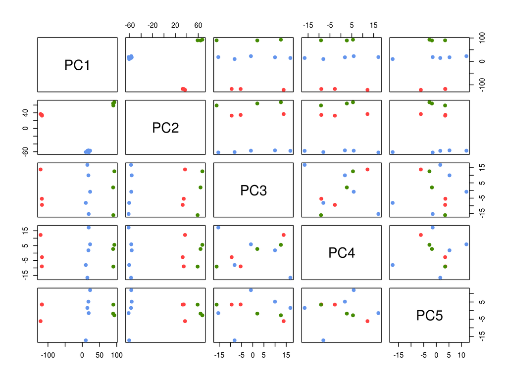

## Differential expression analysis

We applied [limma](http://www.bioconductor.org/packages/release/bioc/html/limma.html) to the data and used a linear modeling approach to identify gene expression changes between the different cell populations. Only celltype was included in the model and we looked at contrasts between the different cell types.

```r
# Get batch corrected data
exprs(gene) <- data.combat

# Fit a linear model
mod<-model.matrix(~celltype -1, data=pd)
fit <- lmFit(gene, mod)

# Define a comtrast model matrix
cont.matrix <- makeContrasts(MEFvsDRG="celltypeMEF-celltypeDRG", MEFvsiNoc="celltypeMEF-celltypeiNoc",
                             iNocvsDRG="celltypeiNoc-celltypeDRG", levels=mod)

# Extract the linear model fit for the contrasts
fit2  <- contrasts.fit(fit, cont.matrix)
fit2  <- eBayes(fit2)

# Set threshold
p.cutoff <- 0.001
logfc.cutoff <- 2

# Get gene tables
MEFvsDRG <- topTable(fit2, coef=1, number=nrow(exprs(gene)))
MEFvsiNoc <- topTable(fit2, coef=2, number=nrow(exprs(gene)))
iNocvsDRG <- topTable(fit2, coef=3, number=nrow(exprs(gene)))
```

### Volcano plots

Gene expression changes were assessed by three different comparisons:

1. mouse embryonic fibrolasts vs dorsal root ganglion
2. mouse embryonic fibroblasts vs induced nociceptor
3. induce nociceptor vs dorsal root ganglion

The third comparison is where would anticipate to see the least amount of change, under the assumption that the transdifferentiation process was successful. Along the same vein, we would probabaly expect to see a good amount of overlap between the genes identified in the first two comparisons. The volcano plots below highlight the findings from each comparison with significant probes (FDR < 0.001; logFC > 2) represented in turquoise.

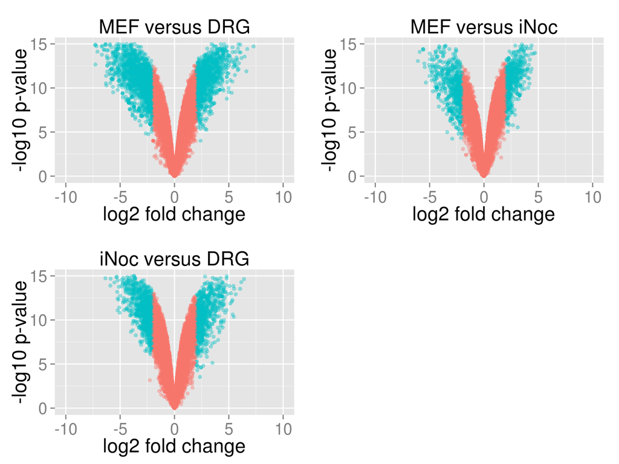

## Significant gene lists

For each of the comparisons, the number of significant probes were tabulated. Further, annotations were retrieved for all probes and only significant probes that mapped to Entrez gene IDs were written to file. These gene lists can be found here:

1. MEF vs iNoc
2. MEF vs DRG
3. DRG vs iNoc

```r
rids <- rownames(exprs(gene))

# Get annotations into matrix
ens <- unlist(mget(rids, mogene10sttranscriptclusterENSEMBL, ifnotfound=NA))
ens <- ens[which(names(ens) %in% rids)] #ensembl is problematic
en <- unlist(mget(names(ens), mogene10sttranscriptclusterENTREZID, ifnotfound=NA))
gn <- unlist(mget(names(ens), mogene10sttranscriptclusterGENENAME, ifnotfound=NA))
sm <- unlist(mget(names(ens), mogene10sttranscriptclusterSYMBOL, ifnotfound=NA))
ann <- data.frame(cbind(entrez=en, genename=gn, symbol=sm, ensembl=ens))

# Merge annotation for each comparison
annot1 <- merge(ann, MEFvsDRG[which(row.names(MEFvsDRG) %in% row.names(ann)),], by.x='row.names', by.y='row.names')
annot2 <- merge(ann, MEFvsiNoc[which(row.names(MEFvsiNoc) %in% row.names(ann)),], by.x='row.names', by.y='row.names')
annot3 <- merge(ann, iNocvsDRG[which(row.names(iNocvsDRG) %in% row.names(ann)),], by.x='row.names', by.y='row.names')
```

### Table of significant findings

The number of significant probes and corresponding number of unique genes from each comparison are listed in the table below:

|  | Significant probes | Significant genes |
| --- | --- | --- |
| MEFvsDRG | 2885 | 2445 |
| MEFvsiNoc | 1199 | 1004 |
| iNocvsDRG | 1652 | 1447 |

### Overlapping significant genes

The number of overlapping genes between the three different comparisons:

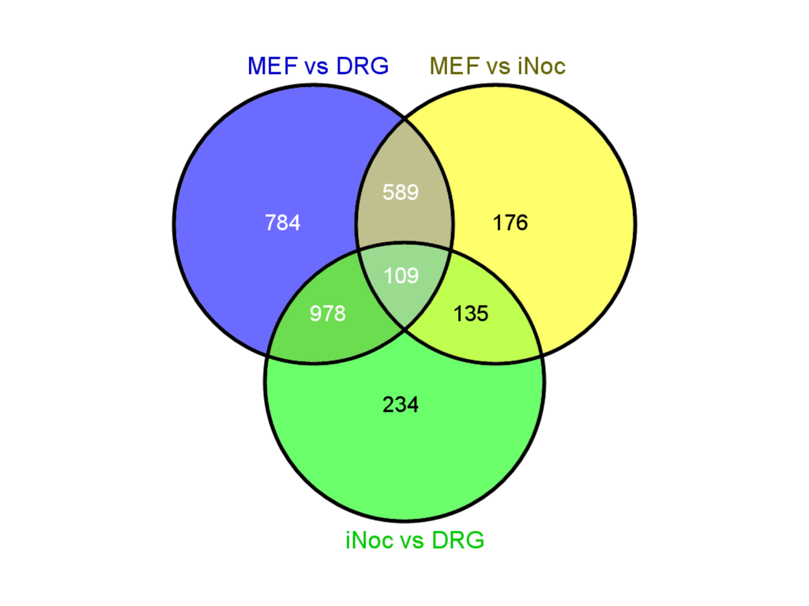

## Enrichment Analysis

For each of the three gene lists we can identify over-represented terms to get an idea of what biological processes and molecular functions are represented. This was done using [GOstats](http://www.bioconductor.org/packages/release/bioc/html/GOstats.html), a Bioconductor package in R. The associated Excel spreadheets for each of the three gene lists are listed below:

- MEFvDRG: Biological process results / Molecular function results
- MEFvsiNoc: Biological process report / Molecular function results
- iNocvsDRG: Biological process report / Molecular function results

```r
genelists <- c("MEFvsDRG", "MEFvsiNoc", "iNocvsDRG")

for (g in 2:3){

  # get significant gene file
  file <- get(paste("annot", g, sep=""))

  # get gene set and gene universe
  entrezUniverse<-unique(file$entrez)
  gsetEntrez <- file$entrez[which(file$threshold.FDR)]

  #Get parameters
  paramsBP <- new("GOHyperGParams", geneIds = unique(gsetEntrez), universeGeneIds = entrezUniverse,
                annotation = "mogene10stprobeset", ontology = "BP", pvalueCutoff = 0.05, conditional = TRUE,
              testDirection = "over")
  paramsMF <- paramsBP
  ontology(paramsMF) <- "MF"
  listOfParamObjs <- list("BP"=GOparams, "MF"=paramsMF)

  # Run test
  resultGOList <- lapply(lisOfParamObjs, hyperGTest)

  # Write to file
  lapply(resultsGOList, function(x){
    write.table(summary(x), file=file.path(resultsDir, paste("GOStats/", genelists[g], "_", names(x), "results.xls",
                                                             sep="")), sep="\t", quote=F, append=FALSE)})
}
```

## iNoc vs DRG

### GO: Biological process

| GOBPID | Pvalue | OddsRatio | ExpCount | Count | Size | Term |
| --- | --- | --- | --- | --- | --- | --- |
| GO:0072359 | 1.707e-23 | 3.077 | 51.381 | 130 | 698 | circulatory system development |
| GO:0051234 | 1.565e-19 | 1.807 | 253.152 | 384 | 3439 | establishment of localization |
| GO:0071840 | 9.141e-16 | 1.659 | 296.289 | 418 | 4025 | cellular component organization or biogenesis |
| GO:0006812 | 1.957e-15 | 2.382 | 61.540 | 127 | 836 | cation transport |
| GO:0023051 | 1.308e-14 | 1.849 | 145.232 | 235 | 1990 | regulation of signaling |
| GO:0010646 | 3.036e-14 | 1.833 | 145.524 | 234 | 1994 | regulation of cell communication |
| GO:0051674 | 4.851e-14 | 2.563 | 44.241 | 98 | 601 | localization of cell |
| GO:0006813 | 3.669e-13 | 4.708 | 10.989 | 40 | 150 | potassium ion transport |
| GO:0034765 | 7.708e-13 | 3.374 | 20.317 | 57 | 276 | regulation of ion transmembrane transport |
| GO:0030199 | 2.402e-12 | 12.747 | 2.797 | 19 | 38 | collagen fibril organization |

### GO: Molecular Function

| GOMFID | Pvalue | OddsRatio | ExpCount | Count | Size | Term |
| --- | --- | --- | --- | --- | --- | --- |
| GO:0005509 | 5.639e-18 | 3.033 | 38.674 | 98 | 525 | calcium ion binding |
| GO:0022803 | 3.295e-14 | 3.139 | 26.961 | 71 | 366 | passive transmembrane transporter activity |
| GO:0022838 | 3.870e-14 | 3.188 | 25.856 | 69 | 351 | substrate-specific channel activity |
| GO:0022836 | 8.267e-14 | 3.704 | 18.222 | 55 | 248 | gated channel activity |
| GO:0005515 | 1.504e-12 | 1.555 | 365.666 | 475 | 5422 | protein binding |
| GO:0005244 | 1.725e-11 | 3.966 | 12.818 | 41 | 174 | voltage-gated ion channel activity |
| GO:0046873 | 4.774e-10 | 3.147 | 17.621 | 47 | 241 | metal ion transmembrane transporter activity |
| GO:0015075 | 1.504e-09 | 2.104 | 49.871 | 94 | 677 | ion transmembrane transporter activity |
| GO:0015077 | 6.249e-08 | 3.159 | 13.014 | 35 | 178 | monovalent inorganic cation transmembrane transporter activity |
| GO:0001968 | 4.243e-07 | 12.661 | 1.473 | 10 | 20 | fibronectin binding |

### Transcription factor enrichment

Since the process of transdifferentiation involves a cocktail of transcription factors, a logical next question that arises is whether there are specific TFs that bind to the regulatory regions in our list of DE genes from the iNocvsDRG comparison. We can check this by pulling all mouse TFs and their target genes from [oPPOSUM](http://burgundy.cmmt.ubc.ca/oPOSSUM/). Using a hypergeometric test we can compare the proportion of differentially expressed genes containing a particular TFBS to the proportion of the background set that contains the site to determine the probability of a non-random association between the gene set and the TFBS of interest. The result is 11 transcription factors that are signficnatly enriched (p < 0.05). The barplot illustrates the number of unique target genes from our list for each ofthe TFs and the associated p-value *(N.B a single target gene may conatin more than one TFBS)*.

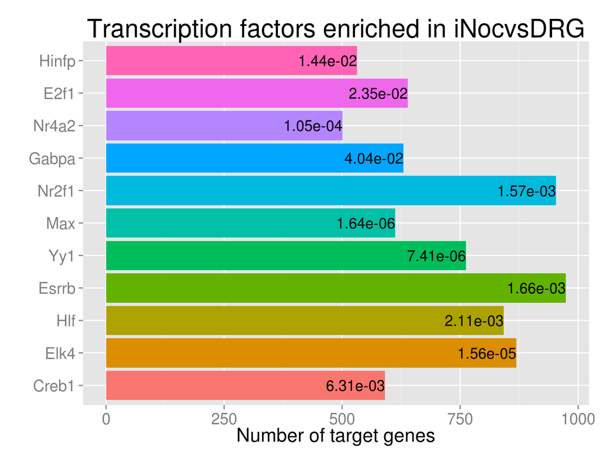

```r
# Get TF list for query genes
list.ens <- as.character(annot3$ensembl[which(annot3$threshold.FDR)])
list.ens <- list.ens[which(!is.na(list.ens))]
tf <- getTFpairs(listgenes = list.ens, filesqlite = '~/remote-sites/mouseTFpairs.db', upstream=1000)

# Get TF list for all genes to set background
all.ens <- as.character(annot3$ensembl)
all.ens <- all.ens[which(!is.na(all.ens))]
# tf.background <- getTFpairs(listgenes = all.ens, filesqlite = '~/remote-sites/mouseTFpairs.db', upstream=1000)
tf.background <- read.delim("supp data//tf_opossum/tfpairs_background", header=T, sep="\t", as.is=T)

# Get hypergeometric p-values for each TF
uniqTF <- unique(as.character(tf$tf))

hyperP <- sapply(uniqTF, function(x){
  q <- length(which(tf$tf == x))
  m <- length(which(tf.background$tf == x))
  n <- nrow(tf.background) - m
  k <- nrow(tf)
  p <- phyper(q -1, m, n, k, lower.tail = TRUE, log.p = FALSE) #prob that observed >= q
  return(p)
})

# get ensembl ids
enrichTF <- uniqTF[which(hyperP < 0.05)]
enrichTF <- enrichTF[order(enrichTF)]

# get number of target genes per tf
enrich.df <- subset(unique(tf[,1:2]), tf %in% enrichTF)
enrich.df <- droplevels(enrich.df)
bar_heights <- summary(enrich.df$tf)

# setup data frame
df_all <- data.frame(tfs = factor(enrichTF))
df_all$bar_heights <- bar_heights[order(names(bar_heights))]
df_all$pval <-  hyperP[match(enrichTF, uniqTF)]
labels <- annot3$symbol[which(annot3$ensembl %in% enrichTF)]

ggplot(df_all) +
  geom_bar(aes(x = tfs, weight = bar_heights, fill=tfs)) +
  coord_flip() +
  scale_x_discrete(breaks=as.character(enrichTF), labels=as.character(labels)) +
  ggtitle('Transcription factors enriched in iNocvsDRG') +
  ylab('Number of target genes') +
  xlab('') +
  guides(fill=FALSE) +
  theme(legend.position="none",
        plot.title = element_text(size = rel(2.0)),
        axis.title = element_text(size = rel(1.5)),
        axis.text = element_text(size = rel(1.25))) +
 geom_text(aes(x=tfs, y=bar_heights, ymax=bar_heights, label=formatC(pval, digits=2, format="e"), hjust= 1))
```